# Heart_disease_analysis

This heart disease dataset is curated by combining 5 popular heart disease datasets already available independently but not combined before. In this dataset, 5 heart datasets are combined over 11 common features which makes it the largest heart disease dataset available so far for research purposes. The five datasets used for its curation are:

Cleveland Hungarian Switzerland Long Beach VA Statlog (Heart) Data Set. This dataset consists of 1190 instances with 11 features. These datasets were collected and combined at one place to help advance research on CAD-related machine learning and data mining algorithms, and hopefully to ultimately advance clinical diagnosis and early treatment.

In the pursuit of enhancing model performance in machine learning, tuning hyperparameters is paramount. Among these parameters, the number of trees holds particular significance in ensemble methods like Random Forests and Extra Trees, influencing both individual tree growth and ensemble behavior.

Traditionally, practitioners turn to exhaustive search techniques like GridSearchCV to pinpoint the optimal hyperparameters. While effective, GridSearchCV can be computationally intensive, particularly for complex models and large datasets. Moreover, it demands significant memory and computational resources, making it impractical for some scenarios.

Fortunately, an alternative methodology exists — one that harnesses the power of visualization to streamline hyperparameter tuning. By visually analyzing the relationships between hyperparameters and model performance, we can gain insights that enable more efficient tuning without the need for exhaustive search methods like GridSearchCV.

For this project, we will use Heart Disease Dataset. As a heart disease is a major concern globally, we will use data exploratory analysis and machine learning to create a model that can identify individuals who might develop heart problems.

```python
import pandas as pd
import numpy as np
import matplotlib.pyplot as plt
import seaborn as sns
import plotly.express as px
from collections import Counter
import optuna

from sklearn.svm import LinearSVC, SVC
from lightgbm import LGBMClassifier
from xgboost import XGBClassifier, XGBRFClassifier
from sklearn.linear_model import LogisticRegression
from sklearn.neural_network import MLPClassifier
from catboost import CatBoostClassifier
from sklearn.ensemble import RandomForestClassifier
from sklearn.ensemble import GradientBoostingClassifier, HistGradientBoostingClassifier, VotingClassifier

from sklearn.preprocessing import StandardScaler, LabelEncoder
from sklearn.model_selection import train_test_split, GridSearchCV, RandomizedSearchCV, cross_val_score
from scipy.stats import reciprocal, uniform
from sklearn.metrics import accuracy_score, confusion_matrix, classification_report, roc_auc_score, roc_curve, auc, r2_score

import warnings
warnings.filterwarnings("ignore")
```

[output not shown]

```python
df = pd.read_csv("heart_statlog_cleveland_hungary_final.csv ")
df.head()
```

|  | age | sex | chest pain type | resting bp s | cholesterol | fasting blood sugar | resting ecg | max heart rate | exercise angina | oldpeak | ST slope | target |
| --- | --- | --- | --- | --- | --- | --- | --- | --- | --- | --- | --- | --- |
| 0 | 40 | 1 | 2 | 140 | 289 | 0 | 0 | 172 | 0 | 0.0 | 1 | 0 |
| 1 | 49 | 0 | 3 | 160 | 180 | 0 | 0 | 156 | 0 | 1.0 | 2 | 1 |
| 2 | 37 | 1 | 2 | 130 | 283 | 0 | 1 | 98 | 0 | 0.0 | 1 | 0 |
| 3 | 48 | 0 | 4 | 138 | 214 | 0 | 0 | 108 | 1 | 1.5 | 2 | 1 |
| 4 | 54 | 1 | 3 | 150 | 195 | 0 | 0 | 122 | 0 | 0.0 | 1 | 0 |

```python
print(f"Total Missing Values : {df.isnull().sum().sum()}")
```

```
Total Missing Values : 0
```

```python
df.info()
```

```
<class 'pandas.core.frame.DataFrame'>
RangeIndex: 1190 entries, 0 to 1189
Data columns (total 12 columns):
 #   Column               Non-Null Count  Dtype
---  ------               --------------  -----
 0   age                  1190 non-null   int64
 1   sex                  1190 non-null   int64
 2   chest pain type      1190 non-null   int64
 3   resting bp s         1190 non-null   int64
 4   cholesterol          1190 non-null   int64
 5   fasting blood sugar  1190 non-null   int64
 6   resting ecg          1190 non-null   int64
 7   max heart rate       1190 non-null   int64
 8   exercise angina      1190 non-null   int64
 9   oldpeak              1190 non-null   float64
 10  ST slope             1190 non-null   int64
 11  target               1190 non-null   int64
dtypes: float64(1), int64(11)
memory usage: 111.7 KB
```

# Distribution of categorical variables

```python
cat_cols = ['sex', 'chest pain type', 'fasting blood sugar', 'resting ecg', 'exercise angina', 'ST slope', 'target']
```

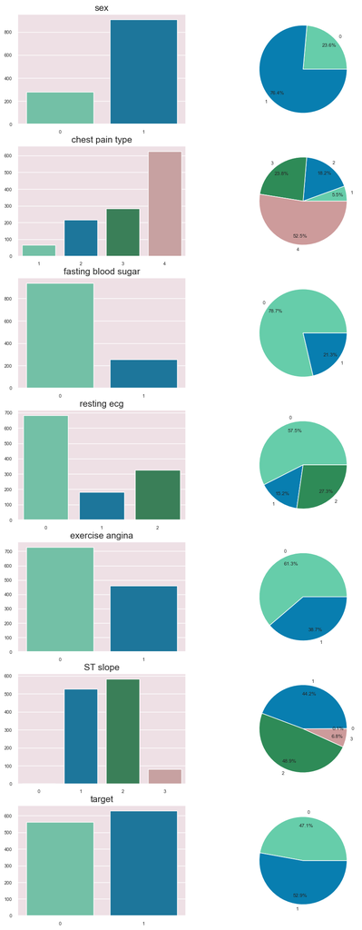

```python
plt.figure(figsize=(11,27))
sns.set(rc={'axes.facecolor':'#eee0e5', 'figure.facecolor':'#ffdab9'}, font_scale=0.7)
clr1 = ["#66cdaa", "#087EB0", "#2e8b57", "#cd9b9b"]
i = 0
j = 1
for col in cat_cols:
    feature = df.groupby(col)[col].count()
    plt.subplot(7, 2, i+1)
    sns.barplot(x=feature.index, y=feature.values, palette=clr1)
    plt.title(col, fontsize=15)
    plt.xlabel("")

    plt.subplot(7, 2, j+1)
    plt.pie(x=feature.values, autopct="%.1f%%", pctdistance=0.8, labels=feature.index,
            colors=["#66cdaa", "#087EB0", "#2e8b57", "#cd9b9b"])
    i += 2
    j += 2
plt.show()
```

# outliers

```python
outlier_list = []

for i in num_cols:
    Q1 = df[i].quantile(0.25)
    Q3 = df[i].quantile(0.75)
    IQR = Q3-Q1
    outlier_step = IQR * 1.5
    index_list = df[(df[i] < Q1 - outlier_step) | (df[i] > Q3 + outlier_step)].index
    outlier_list.extend(index_list)
```

[output not shown]

```python
outlier_list = Counter(outlier_list)
outlier_list = list(outlier_list.items())
multi_out_list = [key for key, value  in outlier_list if value > 1]
```

```python
print(f"Total number of rows with outliers: {len(outlier_list)}")
print(f"Number of rows with outliers in more than one variable :{len(multi_out_list)}")
```

```
Total number of rows with outliers: 0
Number of rows with outliers in more than one variable :0
```

```python
df.drop(multi_out_list, axis=0, inplace=True)
df.reset_index(drop=True, inplace=True)
```

```python
heart_diase_corr = df.corr()["target"]
heart_diase_corr = heart_diase_corr.drop("target", axis=0).sort_values(ascending=False)
```

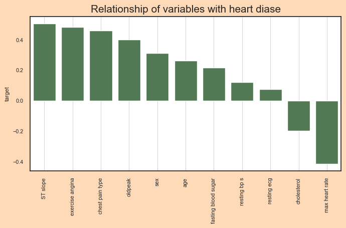

```python
plt.figure(figsize=(8,4))
sns.set_style("white")
sns.barplot(x=heart_diase_corr.index, y=heart_diase_corr, color="#4a804d")
plt.xticks(rotation=90)
plt.grid(True, axis="x", lw=0.6)
plt.title("Relationship of variables with heart diase", fontsize=15)
plt.show()
```

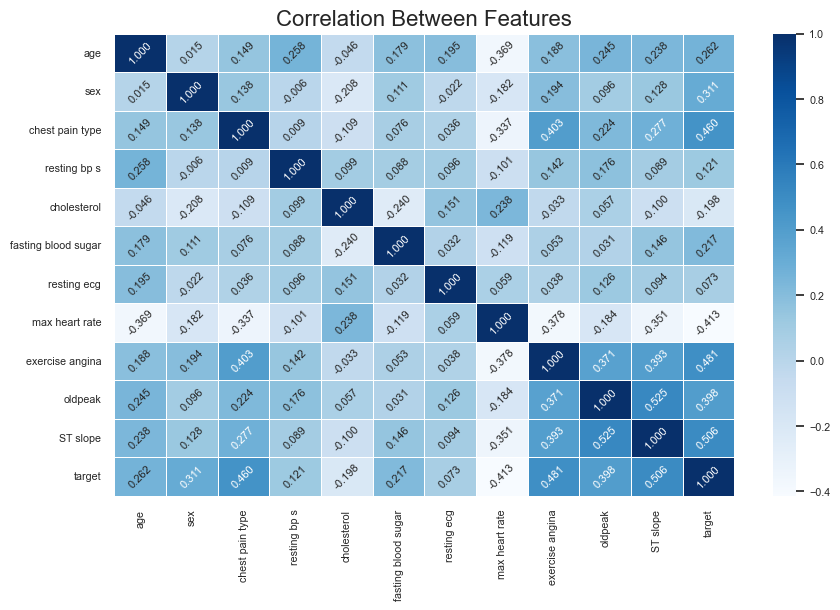

```python
plt.figure(figsize=(10,6))
sns.heatmap(df.corr(), annot=True, linewidths=0.4, fmt='.3f', cmap="Blues", annot_kws={'size': 8, 'rotation': 45})
plt.title("Correlation Between Features", fontsize=16)
plt.show()
```

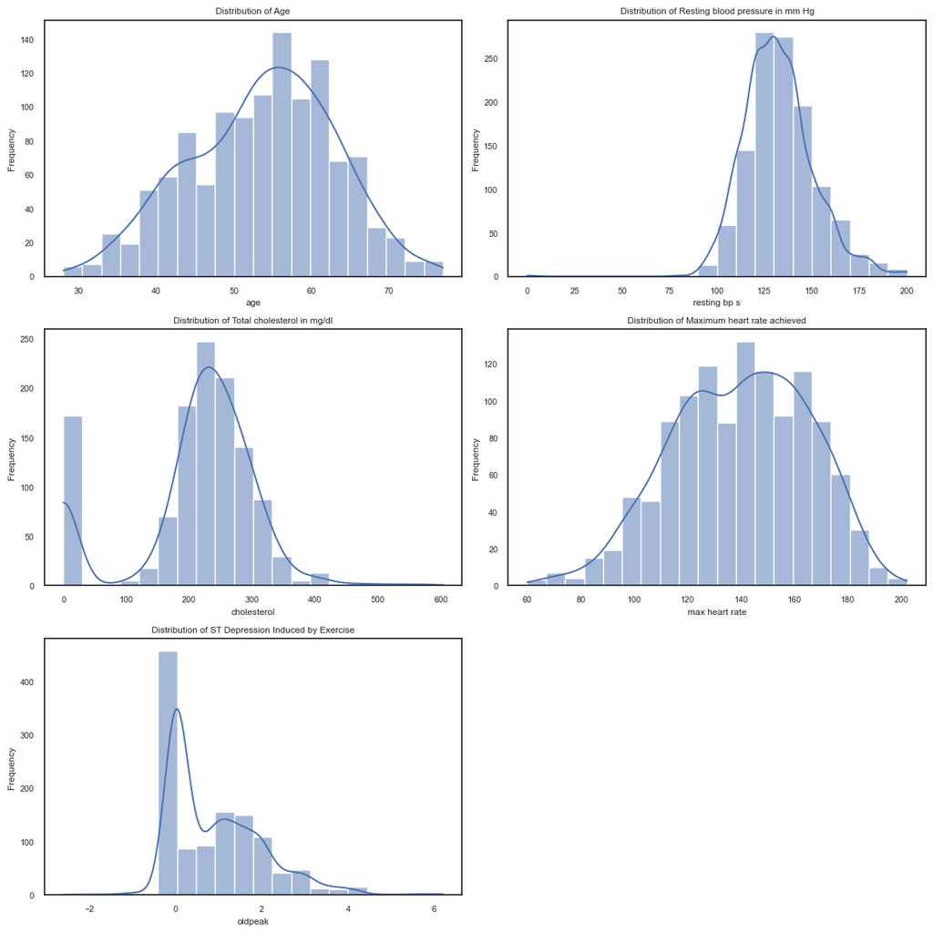

```python
num_columns = ['age', 'resting bp s', 'cholesterol', 'max heart rate', 'oldpeak']
labels = ['Age', 'Resting blood pressure in mm Hg', 'Total cholesterol in mg/dl', 'Maximum heart rate achieved', 'ST Depression Induced by Exercise']

# Set up the plot layout
fig, axes = plt.subplots(nrows=3, ncols=2, figsize=(12, 12))

# Flatten the axes array for easy iteration
axes = axes.flatten()

# Iterate over each column for plotting its distribution using histplot
for i, (column, label) in enumerate(zip(num_columns, labels)):
    sns.histplot(df[column], kde=True, ax=axes[i], bins=20)
    axes[i].set_xlabel(column)
    axes[i].set_ylabel('Frequency')
    axes[i].set_title(f'Distribution of {label}')

# Turn off the last axis
axes[-1].axis('off')

# Adjust layout
plt.tight_layout()
plt.show()
```

observation

Here, we can spot few problems. Column 'Cholesterol' has a high amount of zeros, which is impossible. Resting blood pressure of a person can never be 0, but our data have few zeros. And 'Oldpeak' has a lot zero values, but ST depression can be 0 mV, and is the standard criterion for an abnormal response. The problem that it has negative values.

# distribution of nominal variables

[figure not shown]

```python
nominal_columns = list(set(df.columns) - set(num_columns))
nominal_columns.remove('target')
labels = ['Fasting blood sugar (0=normal, 1=high)', 'Exercise induced angina (0=no, 1=yes)',  'Chest Pain type',
          'Resting electrocardiographic results', 'Sex of patient', 'Slope of peak exercise ST segment']

# Set up the plot layout
fig, axes = plt.subplots(nrows=3, ncols=2, figsize=(14, 16))

# Flatten the axes array for easy iteration
axes = axes.flatten()

# Iterate over each column for plotting its distribution using countplot
for i, (column, label) in enumerate(zip(nominal_columns, labels)):
    sns.countplot(data=df, x=column, hue='target', ax=axes[i], palette='Set2')
    axes[i].set_xlabel(column)
    axes[i].set_ylabel('Count')
    axes[i].legend(title='Target', loc='upper right')
    axes[i].set_title(f'Distribution of {label}')

# Adjust layout
plt.tight_layout()
plt.show()
```